# Ley de Benford

Martin Santamaria

27/8/2020

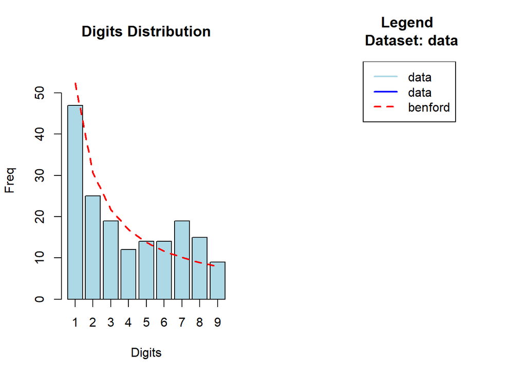

```r
library(benford.analysis)

data = c(1,1,3,5,2,10,3,11,11,9,14,19,31,30,67,41,36,36,86,117,87,101,55,75,146,88,79,132,88,98,103,74,87,80,99,81,167,66,69,166,128,98,88,81,102,90,112,144,147,172,173,112,111,124,158,143,105,149,103,104,134,188,163,240,165,258,244,285,316,255,345,327,263,303,438,474,648,718,704,723,552,600,706,769,717,795,637,564,904,949,929,840,983,774,826,1141,1226,1386,1391,1531,1282,1208,1374,1393,1958,1634,2060,1581,2146,2285,2635,2606,2886,2401,2189,2335,2262,2667,2744,2845,2590,2439,2632,2979,3604,3663,3367,3449,2657,3099,3645,4250,3624,4518,3223,4231,3937,5344,5782,6127,5493,4192,4814,4890,5939,5641,6377,5929,5241,5376,4824,6792,7147,7513,7482,6134,4688,7369,7043,7663,7498,6365,6663,5469,4557,6840,6693,8225,8159,7759,5352,8713,8771,10550)

bd <- benford(data = data, number.of.digits = 1)

plot(bd,except=c("second order", "summation","mantissa","chi squared","abs diff","ex summation"))
```

### 1)

$840 \ \vert \ 2 \\ 420 \ \vert \ 2 \\ 210 \ \vert \ 2 \\ 105 \ \vert \ 3 \\ \ \ 35 \ \vert \ 5 \\ \ \ \ \ 7 \ \vert \ 7 \\ \ \ \ \ 1 \ \vert$

$840 = 2^3 \cdot 3 \cdot 5 \cdot 7$

### 2)

$3675 \ \vert \ 3 \\ 1225 \ \vert \ 5 \\ \ \ 245 \ \vert \ 5 \\ \ \ \ \ 49 \ \vert \ 7 \\ \ \ \ \ \ \ 7 \ \vert \ 7 \\ \ \ \ \ \ \ 1 \ \vert$

$3675 = 3 \cdot 5^2 \cdot 7^2$

### 3)

$2376 \ \vert \ 2 \\ 1188 \ \vert \ 2 \\ \ \ 594 \ \vert \ 2 \\ \ \ 297 \ \vert \ 3 \\ \ \ \ \ 99 \ \vert \ 3 \\ \ \ \ \ 33 \ \vert \ 3 \ \\ \ \ \ \ 11 \ \vert \ 11 \\ \ \ \ \ \ \ 1 \ \vert$

$2376 = 2^3 \cdot 3^3 \cdot 11$

### 4)

$7020 \ \vert \ 2 \\ 3510 \ \vert \ 2 \\ 1755 \ \vert \ 3 \\ \ \ 585 \ \vert \ 3 \\ \ \ 195 \ \vert \ 3 \\ \ \ \ \ 65 \ \vert \ 5 \ \\ \ \ \ \ 13 \ \vert \ 13 \\ \ \ \ \ \ \ 1 \ \vert$

$7020 = 2^2 \cdot 3^3 \cdot 5 \cdot 13$

### 5)

$29400 \ \vert \ 2 \\ 14700 \ \vert \ 2 \\ \ \ 7350 \ \vert \ 2 \\ \ \ 3675 \ \vert \ 3 \\ \ \ 1225 \ \vert \ 5 \\ \ \ \ \ 245 \ \vert \ 5 \ \\ \ \ \ \ \ \ 49 \ \vert \ 7 \\ \ \ \ \ \ \ \ \ 7 \ \vert \ 7 \\ \ \ \ \ \ \ \ \ 1 \ \vert$

$29400 = 2^3 \cdot 3 \cdot 5^2 \cdot 7^2$